# US airline passengers from 1949 to 1960

Introduction

- The classic Box & Jenkins airline data. Monthly totals of international airline passengers, 1949 to 1960
- This dataset is taken from an inbuilt dataset of R called AirPassengers
- This dataset provides monthly totals of a US airline passengers from 1949 to 1960. Total number of passengers  
  travelled on that particular month

# Load Data & Plot

```r
data(AirPassengers)
```

```r
dataSet<-AirPassengers
```

```r
dataSet
```

[output not shown]

|  | Jan | Feb | Mar | Apr | May | Jun | Jul | Aug | Sep | Oct | Nov | Dec |
| --- | --- | --- | --- | --- | --- | --- | --- | --- | --- | --- | --- | --- |
| 1949 | 112 | 118 | 132 | 129 | 121 | 135 | 148 | 148 | 136 | 119 | 104 | 118 |
| 1950 | 115 | 126 | 141 | 135 | 125 | 149 | 170 | 170 | 158 | 133 | 114 | 140 |
| 1951 | 145 | 150 | 178 | 163 | 172 | 178 | 199 | 199 | 184 | 162 | 146 | 166 |
| 1952 | 171 | 180 | 193 | 181 | 183 | 218 | 230 | 242 | 209 | 191 | 172 | 194 |
| 1953 | 196 | 196 | 236 | 235 | 229 | 243 | 264 | 272 | 237 | 211 | 180 | 201 |
| 1954 | 204 | 188 | 235 | 227 | 234 | 264 | 302 | 293 | 259 | 229 | 203 | 229 |
| 1955 | 242 | 233 | 267 | 269 | 270 | 315 | 364 | 347 | 312 | 274 | 237 | 278 |
| 1956 | 284 | 277 | 317 | 313 | 318 | 374 | 413 | 405 | 355 | 306 | 271 | 306 |
| 1957 | 315 | 301 | 356 | 348 | 355 | 422 | 465 | 467 | 404 | 347 | 305 | 336 |
| 1958 | 340 | 318 | 362 | 348 | 363 | 435 | 491 | 505 | 404 | 359 | 310 | 337 |
| 1959 | 360 | 342 | 406 | 396 | 420 | 472 | 548 | 559 | 463 | 407 | 362 | 405 |
| 1960 | 417 | 391 | 419 | 461 | 472 | 535 | 622 | 606 | 508 | 461 | 390 | 432 |

```r
#The below cammond is to now about the basic structure in data, also to know nature of this dataset

class(dataSet) #ts - time series
```

'ts'

```r
str(dataSet) #it gives structure of a dataset
```

```
 Time-Series [1:144] from 1949 to 1961: 112 118 132 129 121 135 148 148 136 119 ...
```

```r
attributes(dataSet)
```

**$tsp**

1. 1949

2. 1960.91666666667

3. 12

**$class**

'ts'

```r
start(dataSet)
```

1. 1949

2. 1

```r
end(dataSet)
```

1. 1960

2. 12

```r
mode(dataSet)
```

'numeric'

```r
frequency(dataSet) #total_no of months
```

12

```r
summary(dataSet)
```

```
   Min. 1st Qu.  Median    Mean 3rd Qu.    Max.
  104.0   180.0   265.5   280.3   360.5   622.0
```

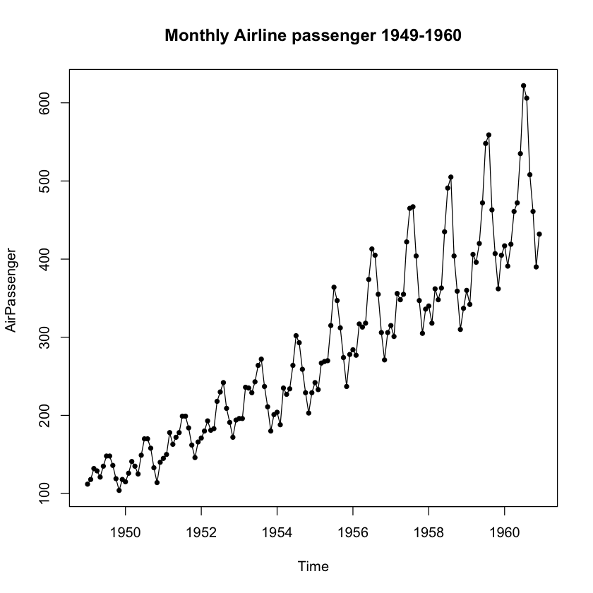

```r
plot(dataSet,ylab="AirPassenger ",type="o",pch = 20,main = "Monthly Airline passenger 1949-1960")
```

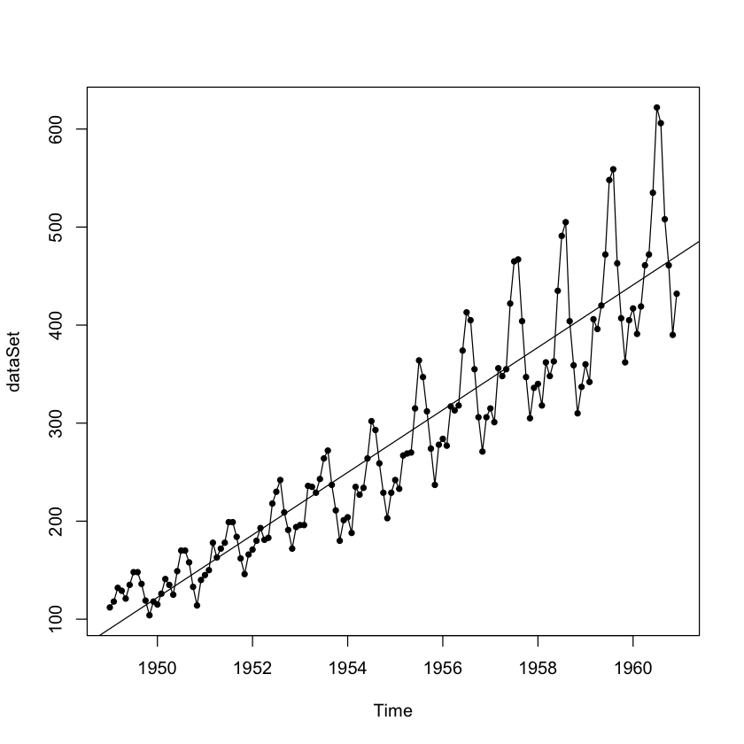

```r
# reg=regression model,lm=linear modeling
plot(dataSet,type="o",pch=20)
abline(reg = lm(dataSet~time(dataSet)))
```

- In this plot representation, if we put a trend line i.e, connecting means of all the points.
- In this dataset the varience changes at every point.
- My data is not standard or stationary, so we can't apply Time Series to it.
- To make the data as stationary, the varience should be equal
  1. One, we need to remove unequal variances. We do this using log of the series
  2. we need to address the trend component. We do this by taking difference of the series. Now, let’s test the resultant series.

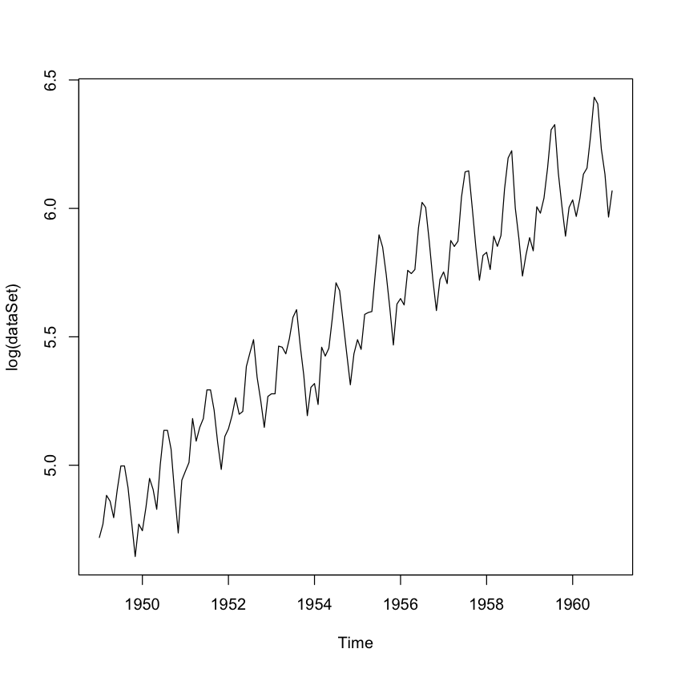

```r
plot(log(dataSet))
```

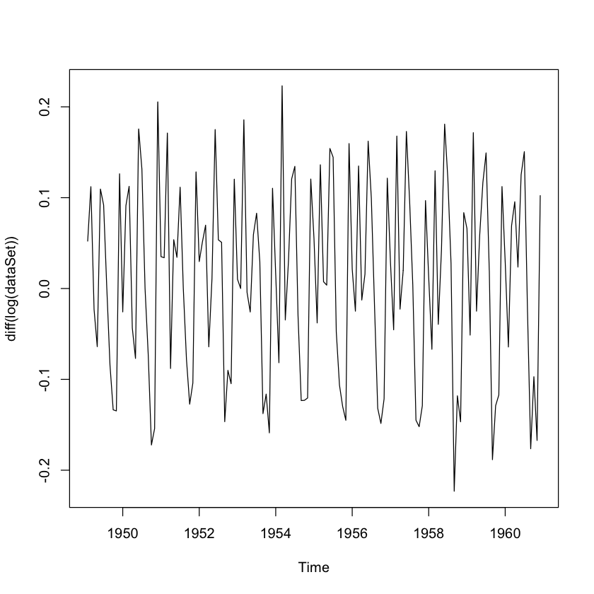

```r
plot(diff(log(dataSet)))
```

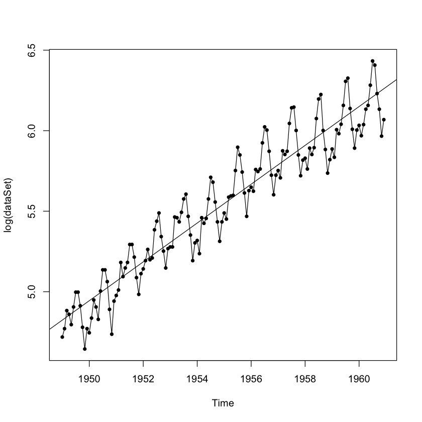

```r
plot(log(dataSet),type="o",pch=20)
abline(reg=lm(log(dataSet)~time(dataSet)))
```

```r
cycle(dataSet) #cycle cammond will print cycle across the year
```

[output not shown]

|  | Jan | Feb | Mar | Apr | May | Jun | Jul | Aug | Sep | Oct | Nov | Dec |
| --- | --- | --- | --- | --- | --- | --- | --- | --- | --- | --- | --- | --- |
| 1949 | 1 | 2 | 3 | 4 | 5 | 6 | 7 | 8 | 9 | 10 | 11 | 12 |
| 1950 | 1 | 2 | 3 | 4 | 5 | 6 | 7 | 8 | 9 | 10 | 11 | 12 |
| 1951 | 1 | 2 | 3 | 4 | 5 | 6 | 7 | 8 | 9 | 10 | 11 | 12 |
| 1952 | 1 | 2 | 3 | 4 | 5 | 6 | 7 | 8 | 9 | 10 | 11 | 12 |
| 1953 | 1 | 2 | 3 | 4 | 5 | 6 | 7 | 8 | 9 | 10 | 11 | 12 |
| 1954 | 1 | 2 | 3 | 4 | 5 | 6 | 7 | 8 | 9 | 10 | 11 | 12 |
| 1955 | 1 | 2 | 3 | 4 | 5 | 6 | 7 | 8 | 9 | 10 | 11 | 12 |
| 1956 | 1 | 2 | 3 | 4 | 5 | 6 | 7 | 8 | 9 | 10 | 11 | 12 |
| 1957 | 1 | 2 | 3 | 4 | 5 | 6 | 7 | 8 | 9 | 10 | 11 | 12 |
| 1958 | 1 | 2 | 3 | 4 | 5 | 6 | 7 | 8 | 9 | 10 | 11 | 12 |
| 1959 | 1 | 2 | 3 | 4 | 5 | 6 | 7 | 8 | 9 | 10 | 11 | 12 |
| 1960 | 1 | 2 | 3 | 4 | 5 | 6 | 7 | 8 | 9 | 10 | 11 | 12 |

```r
time(dataSet) #it gives us a year names
```

[output not shown]

|  | Jan | Feb | Mar | Apr | May | Jun | Jul | Aug | Sep | Oct | Nov | Dec |
| --- | --- | --- | --- | --- | --- | --- | --- | --- | --- | --- | --- | --- |
| 1949 | 1949.000 | 1949.083 | 1949.167 | 1949.250 | 1949.333 | 1949.417 | 1949.500 | 1949.583 | 1949.667 | 1949.750 | 1949.833 | 1949.917 |
| 1950 | 1950.000 | 1950.083 | 1950.167 | 1950.250 | 1950.333 | 1950.417 | 1950.500 | 1950.583 | 1950.667 | 1950.750 | 1950.833 | 1950.917 |
| 1951 | 1951.000 | 1951.083 | 1951.167 | 1951.250 | 1951.333 | 1951.417 | 1951.500 | 1951.583 | 1951.667 | 1951.750 | 1951.833 | 1951.917 |
| 1952 | 1952.000 | 1952.083 | 1952.167 | 1952.250 | 1952.333 | 1952.417 | 1952.500 | 1952.583 | 1952.667 | 1952.750 | 1952.833 | 1952.917 |
| 1953 | 1953.000 | 1953.083 | 1953.167 | 1953.250 | 1953.333 | 1953.417 | 1953.500 | 1953.583 | 1953.667 | 1953.750 | 1953.833 | 1953.917 |
| 1954 | 1954.000 | 1954.083 | 1954.167 | 1954.250 | 1954.333 | 1954.417 | 1954.500 | 1954.583 | 1954.667 | 1954.750 | 1954.833 | 1954.917 |
| 1955 | 1955.000 | 1955.083 | 1955.167 | 1955.250 | 1955.333 | 1955.417 | 1955.500 | 1955.583 | 1955.667 | 1955.750 | 1955.833 | 1955.917 |
| 1956 | 1956.000 | 1956.083 | 1956.167 | 1956.250 | 1956.333 | 1956.417 | 1956.500 | 1956.583 | 1956.667 | 1956.750 | 1956.833 | 1956.917 |
| 1957 | 1957.000 | 1957.083 | 1957.167 | 1957.250 | 1957.333 | 1957.417 | 1957.500 | 1957.583 | 1957.667 | 1957.750 | 1957.833 | 1957.917 |
| 1958 | 1958.000 | 1958.083 | 1958.167 | 1958.250 | 1958.333 | 1958.417 | 1958.500 | 1958.583 | 1958.667 | 1958.750 | 1958.833 | 1958.917 |
| 1959 | 1959.000 | 1959.083 | 1959.167 | 1959.250 | 1959.333 | 1959.417 | 1959.500 | 1959.583 | 1959.667 | 1959.750 | 1959.833 | 1959.917 |
| 1960 | 1960.000 | 1960.083 | 1960.167 | 1960.250 | 1960.333 | 1960.417 | 1960.500 | 1960.583 | 1960.667 | 1960.750 | 1960.833 | 1960.917 |

```r
log(dataSet)
```

[output not shown]

|  | Jan | Feb | Mar | Apr | May | Jun | Jul | Aug | Sep | Oct | Nov | Dec |
| --- | --- | --- | --- | --- | --- | --- | --- | --- | --- | --- | --- | --- |
| 1949 | 4.718499 | 4.770685 | 4.882802 | 4.859812 | 4.795791 | 4.905275 | 4.997212 | 4.997212 | 4.912655 | 4.779123 | 4.644391 | 4.770685 |
| 1950 | 4.744932 | 4.836282 | 4.948760 | 4.905275 | 4.828314 | 5.003946 | 5.135798 | 5.135798 | 5.062595 | 4.890349 | 4.736198 | 4.941642 |
| 1951 | 4.976734 | 5.010635 | 5.181784 | 5.093750 | 5.147494 | 5.181784 | 5.293305 | 5.293305 | 5.214936 | 5.087596 | 4.983607 | 5.111988 |
| 1952 | 5.141664 | 5.192957 | 5.262690 | 5.198497 | 5.209486 | 5.384495 | 5.438079 | 5.488938 | 5.342334 | 5.252273 | 5.147494 | 5.267858 |
| 1953 | 5.278115 | 5.278115 | 5.463832 | 5.459586 | 5.433722 | 5.493061 | 5.575949 | 5.605802 | 5.468060 | 5.351858 | 5.192957 | 5.303305 |
| 1954 | 5.318120 | 5.236442 | 5.459586 | 5.424950 | 5.455321 | 5.575949 | 5.710427 | 5.680173 | 5.556828 | 5.433722 | 5.313206 | 5.433722 |
| 1955 | 5.488938 | 5.451038 | 5.587249 | 5.594711 | 5.598422 | 5.752573 | 5.897154 | 5.849325 | 5.743003 | 5.613128 | 5.468060 | 5.627621 |
| 1956 | 5.648974 | 5.624018 | 5.758902 | 5.746203 | 5.762051 | 5.924256 | 6.023448 | 6.003887 | 5.872118 | 5.723585 | 5.602119 | 5.723585 |
| 1957 | 5.752573 | 5.707110 | 5.874931 | 5.852202 | 5.872118 | 6.045005 | 6.142037 | 6.146329 | 6.001415 | 5.849325 | 5.720312 | 5.817111 |
| 1958 | 5.828946 | 5.762051 | 5.891644 | 5.852202 | 5.894403 | 6.075346 | 6.196444 | 6.224558 | 6.001415 | 5.883322 | 5.736572 | 5.820083 |
| 1959 | 5.886104 | 5.834811 | 6.006353 | 5.981414 | 6.040255 | 6.156979 | 6.306275 | 6.326149 | 6.137727 | 6.008813 | 5.891644 | 6.003887 |
| 1960 | 6.033086 | 5.968708 | 6.037871 | 6.133398 | 6.156979 | 6.282267 | 6.432940 | 6.406880 | 6.230481 | 6.133398 | 5.966147 | 6.068426 |

```r
diff(log(dataSet))
```

[output not shown]

|  | Jan | Feb | Mar | Apr | May | Jun | Jul | Aug | Sep | Oct | Nov | Dec |
| --- | --- | --- | --- | --- | --- | --- | --- | --- | --- | --- | --- | --- |
| 1949 |  | 0.052185753 | 0.112117298 | -0.022989518 | -0.064021859 | 0.109484233 | 0.091937495 | 0.000000000 | -0.084557388 | -0.133531393 | -0.134732594 | 0.126293725 |
| 1950 | -0.025752496 | 0.091349779 | 0.112477983 | -0.043485112 | -0.076961041 | 0.175632569 | 0.131852131 | 0.000000000 | -0.073203404 | -0.172245905 | -0.154150680 | 0.205443974 |
| 1951 | 0.035091320 | 0.033901552 | 0.171148256 | -0.088033349 | 0.053744276 | 0.034289073 | 0.111521274 | 0.000000000 | -0.078369067 | -0.127339422 | -0.103989714 | 0.128381167 |
| 1952 | 0.029675768 | 0.051293294 | 0.069733338 | -0.064193158 | 0.010989122 | 0.175008910 | 0.053584246 | 0.050858417 | -0.146603474 | -0.090060824 | -0.104778951 | 0.120363682 |
| 1953 | 0.010256500 | 0.000000000 | 0.185717146 | -0.004246291 | -0.025863511 | 0.059339440 | 0.082887660 | 0.029852963 | -0.137741925 | -0.116202008 | -0.158901283 | 0.110348057 |
| 1954 | 0.014815086 | -0.081678031 | 0.223143551 | -0.034635497 | 0.030371098 | 0.120627988 | 0.134477914 | -0.030254408 | -0.123344547 | -0.123106058 | -0.120516025 | 0.120516025 |
| 1955 | 0.055215723 | -0.037899273 | 0.136210205 | 0.007462721 | 0.003710579 | 0.154150680 | 0.144581229 | -0.047829088 | -0.106321592 | -0.129875081 | -0.145067965 | 0.159560973 |
| 1956 | 0.021353124 | -0.024956732 | 0.134884268 | -0.012698583 | 0.015848192 | 0.162204415 | 0.099191796 | -0.019560526 | -0.131769278 | -0.148532688 | -0.121466281 | 0.121466281 |
| 1957 | 0.028987537 | -0.045462374 | 0.167820466 | -0.022728251 | 0.019915310 | 0.172887525 | 0.097032092 | 0.004291852 | -0.144914380 | -0.152090098 | -0.129013003 | 0.096799383 |
| 1958 | 0.011834458 | -0.066894235 | 0.129592829 | -0.039441732 | 0.042200354 | 0.180943197 | 0.121098097 | 0.028114301 | -0.223143551 | -0.118092489 | -0.146750091 | 0.083510633 |
| 1959 | 0.066021101 | -0.051293294 | 0.171542423 | -0.024938948 | 0.058840500 | 0.116724274 | 0.149296301 | 0.019874186 | -0.188422419 | -0.128913869 | -0.117168974 | 0.112242855 |
| 1960 | 0.029199155 | -0.064378662 | 0.069163360 | 0.095527123 | 0.023580943 | 0.125287761 | 0.150673346 | -0.026060107 | -0.176398538 | -0.097083405 | -0.167251304 | 0.102278849 |

Interpretation Seasonality appears to increase with the general trend suggesting a multiplicative model rather than an additive model, i.e:

Y(t)=T(t)∗S(t)∗e(t)

where,

- Y(t) is the number of passengers at time t,
- T(t) is the trend component at time t,
- S(t) is the seasonal component at time t,
- and e(t) is the random error component at time t.

# Decomposing the Data

Decomposing the data into its trend, seasonal, and random error components will give some idea how these components relate to the observed dataset.

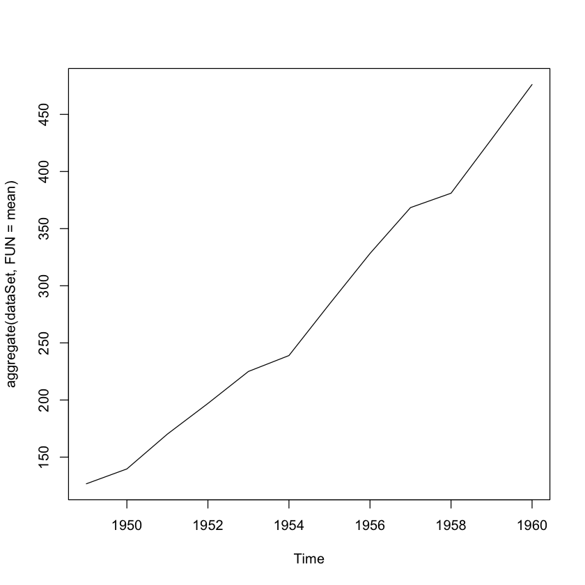

```r
#plot an year on year general trend
plot(aggregate(dataSet,FUN = mean))
```

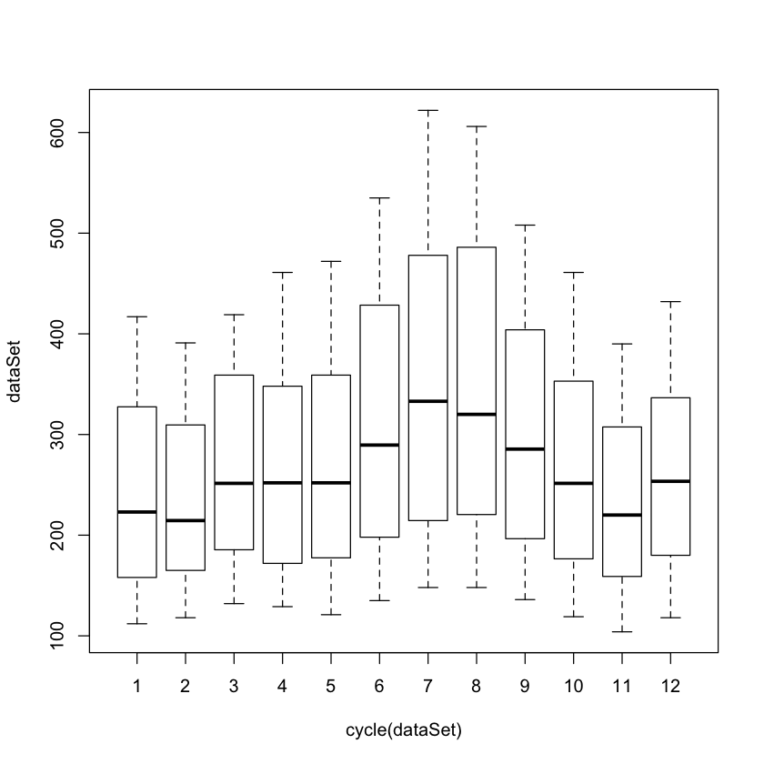

```r
boxplot(dataSet~cycle(dataSet))
```

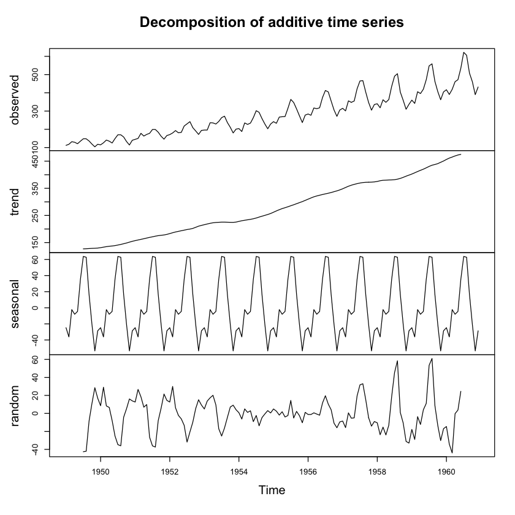

```r
plot(decompose(dataSet))
```

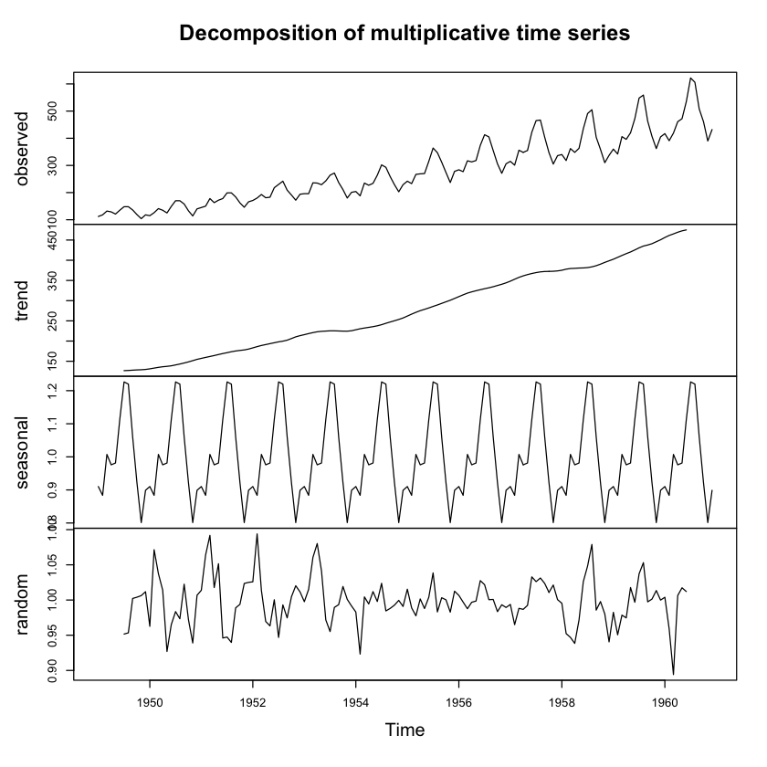

```r
plot(decompose(dataSet,type="multiplicative"))
```

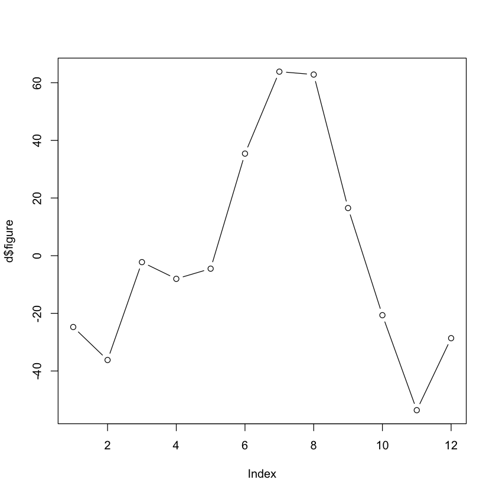

```r
a<-ts(dataSet,frequency = 12)
d<-decompose(a)
plot(d$figure,type="b") #seasonal figures
```

# Time Series Forecating

- To forecast future events based on known past data
- for example, to predict a price of a stock on a past performance
- their are two popular model:
1. ARMA (Autoregressive moving average)
2. ARIMA (Autoregressive integrated moving average)

```r
library(tseries)
```

- We see that the series is stationary enough to do any kind of time series modelling.

```r
adf.test(diff(log(AirPassengers)), alternative="stationary", k=0)
```

```
	Augmented Dickey-Fuller Test

data:  diff(log(AirPassengers))
Dickey-Fuller = -9.6003, Lag order = 0, p-value = 0.01
alternative hypothesis: stationary
```

Now, to find the right parameters to be used in the ARIMA model. We already know that the ‘d’ component is 1 as we need 1 difference to make the series stationary. We do this using the Correlation plots. Following are the ACF plots for the series

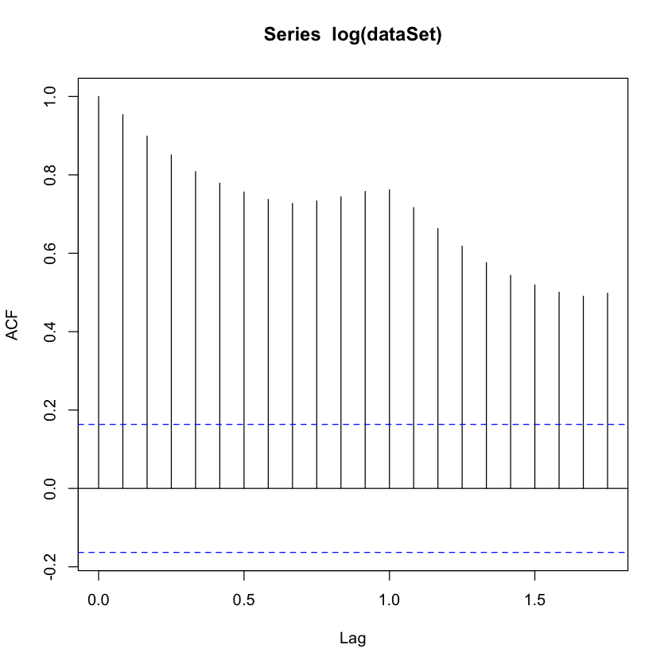

```r
# the fuction acf() compute an estimate of autocorrelation of time series.
acf(log(dataSet))
```

1. By above graph we see that, the decay of ACF chart is very slow, which means that the population is not stationary.
2. We have already discussed above that we now intend to regress on the difference of logs rather than log directly.

Let’s see how ACF and PACF curve come out after regressing on the difference

- AR I MA (autoregression integrated moving average)
- p ,d,q (value to be included, to auto correlation function graph)

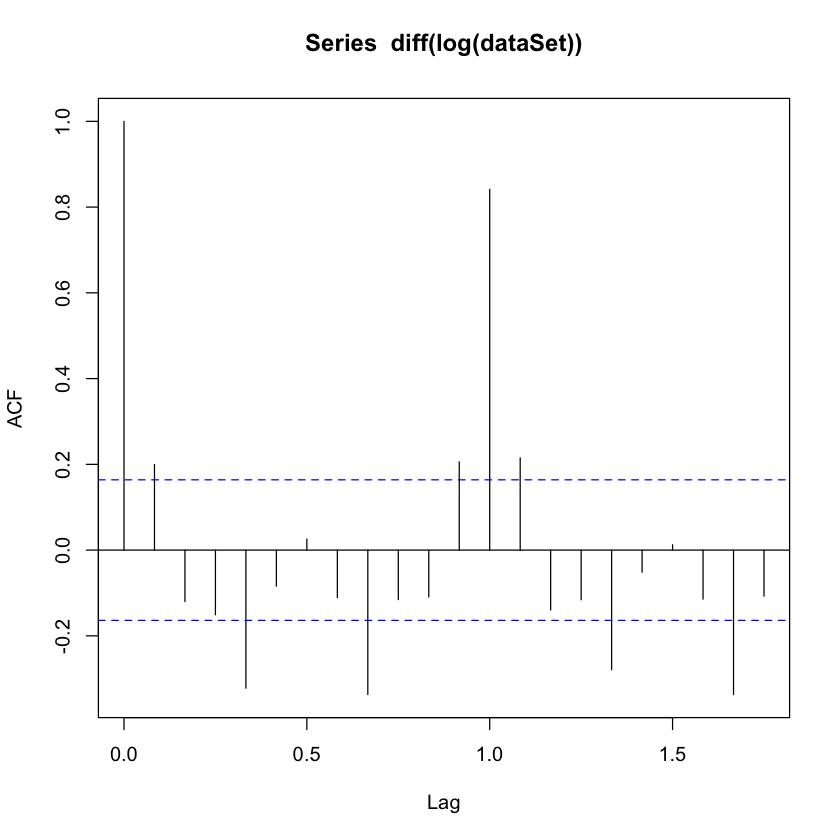

```r
acf(diff(log(dataSet))) # determine the q value i.e, q=1
```

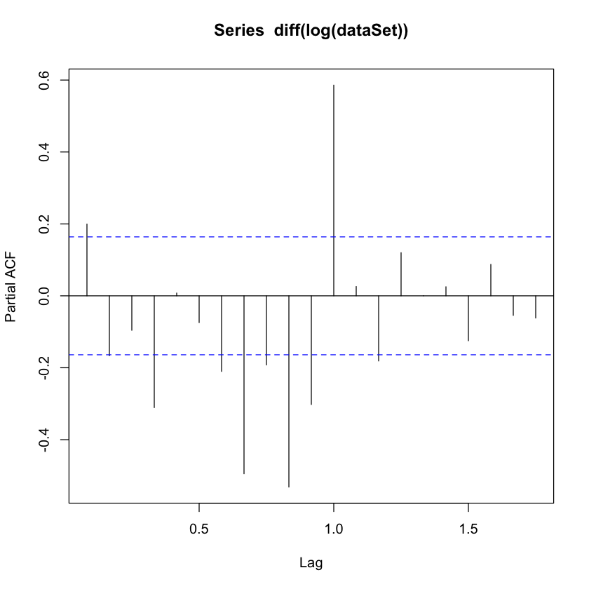

```r
#the pacf compute an estimate of the partial autocorrelation
#function of a (possibly multivariate) time series.
pacf(diff(log(dataSet))) #determine thep value i.e, p=0
```

the d value comes from number of times you do the differentiate. In this case d=1

Let’s fit an ARIMA model and predict the future 10 years. Also, we will try fitting in a seasonal component in the ARIMA formulation. Then, we will visualize the prediction along with the training data.

c(p,d,q)=c(0,1,1)

```r
fitArima=arima(log(dataSet),c(0,1,1),seasonal = list(order=c(0,1,1),period=12))
```

```r
fitArima
```

```
Call:
arima(x = log(dataSet), order = c(0, 1, 1), seasonal = list(order = c(0, 1,
    1), period = 12))

Coefficients:
          ma1     sma1
      -0.4018  -0.5569
s.e.   0.0896   0.0731

sigma^2 estimated as 0.001348:  log likelihood = 244.7,  aic = -483.4
```

```r
pred <- predict(fitArima, n.ahead = 10*12)
```

```r
# the prediction values are in logarithmic form
# to convert it into a original form we need to transform the e value i.e, 2.718

pred
```

[output not shown]

**$pred**

|  | Jan | Feb | Mar | Apr | May | Jun | Jul | Aug | Sep | Oct | Nov | Dec |
| --- | --- | --- | --- | --- | --- | --- | --- | --- | --- | --- | --- | --- |
| 1961 | 6.110186 | 6.053775 | 6.171715 | 6.199300 | 6.232556 | 6.368779 | 6.507294 | 6.502906 | 6.324698 | 6.209008 | 6.063487 | 6.168025 |
| 1962 | 6.206435 | 6.150025 | 6.267964 | 6.295550 | 6.328805 | 6.465028 | 6.603543 | 6.599156 | 6.420947 | 6.305257 | 6.159737 | 6.264274 |
| 1963 | 6.302684 | 6.246274 | 6.364213 | 6.391799 | 6.425054 | 6.561277 | 6.699792 | 6.695405 | 6.517197 | 6.401507 | 6.255986 | 6.360523 |
| 1964 | 6.398933 | 6.342523 | 6.460463 | 6.488048 | 6.521304 | 6.657526 | 6.796042 | 6.791654 | 6.613446 | 6.497756 | 6.352235 | 6.456773 |
| 1965 | 6.495183 | 6.438772 | 6.556712 | 6.584297 | 6.617553 | 6.753776 | 6.892291 | 6.887903 | 6.709695 | 6.594005 | 6.448484 | 6.553022 |
| 1966 | 6.591432 | 6.535022 | 6.652961 | 6.680547 | 6.713802 | 6.850025 | 6.988540 | 6.984153 | 6.805944 | 6.690254 | 6.544734 | 6.649271 |
| 1967 | 6.687681 | 6.631271 | 6.749210 | 6.776796 | 6.810051 | 6.946274 | 7.084789 | 7.080402 | 6.902194 | 6.786504 | 6.640983 | 6.745520 |
| 1968 | 6.783930 | 6.727520 | 6.845460 | 6.873045 | 6.906301 | 7.042523 | 7.181039 | 7.176651 | 6.998443 | 6.882753 | 6.737232 | 6.841770 |
| 1969 | 6.880180 | 6.823769 | 6.941709 | 6.969294 | 7.002550 | 7.138773 | 7.277288 | 7.272900 | 7.094692 | 6.979002 | 6.833481 | 6.938019 |
| 1970 | 6.976429 | 6.920019 | 7.037958 | 7.065544 | 7.098799 | 7.235022 | 7.373537 | 7.369150 | 7.190941 | 7.075251 | 6.929731 | 7.034268 |

**$se**

|  | Jan | Feb | Mar | Apr | May | Jun | Jul | Aug | Sep | Oct | Nov | Dec |
| --- | --- | --- | --- | --- | --- | --- | --- | --- | --- | --- | --- | --- |
| 1961 | 0.03671562 | 0.04278291 | 0.04809072 | 0.05286830 | 0.05724856 | 0.06131670 | 0.06513124 | 0.06873441 | 0.07215787 | 0.07542612 | 0.07855851 | 0.08157070 |
| 1962 | 0.09008475 | 0.09549708 | 0.10061869 | 0.10549195 | 0.11014981 | 0.11461854 | 0.11891946 | 0.12307018 | 0.12708540 | 0.13097758 | 0.13475740 | 0.13843405 |
| 1963 | 0.14650643 | 0.15224985 | 0.15778435 | 0.16313118 | 0.16830825 | 0.17333075 | 0.17821177 | 0.18296261 | 0.18759318 | 0.19211216 | 0.19652727 | 0.20084534 |
| 1964 | 0.20896657 | 0.21513653 | 0.22113442 | 0.22697386 | 0.23266679 | 0.23822371 | 0.24365393 | 0.24896574 | 0.25416656 | 0.25926308 | 0.26426132 | 0.26916676 |
| 1965 | 0.27748210 | 0.28408309 | 0.29053414 | 0.29684503 | 0.30302451 | 0.30908048 | 0.31502004 | 0.32084967 | 0.32657525 | 0.33220217 | 0.33773535 | 0.34317933 |
| 1966 | 0.35174476 | 0.35876289 | 0.36564634 | 0.37240257 | 0.37903840 | 0.38556004 | 0.39197318 | 0.39828307 | 0.40449455 | 0.41061207 | 0.41663978 | 0.42258152 |
| 1967 | 0.43142043 | 0.43883816 | 0.44613258 | 0.45330963 | 0.46037481 | 0.46733319 | 0.47418947 | 0.48094803 | 0.48761291 | 0.49418791 | 0.50067658 | 0.50708223 |
| 1968 | 0.51620376 | 0.52400376 | 0.53168935 | 0.53926541 | 0.54673651 | 0.55410688 | 0.56138049 | 0.56856106 | 0.57565206 | 0.58265678 | 0.58957827 | 0.59641945 |
| 1969 | 0.60582584 | 0.61399203 | 0.62205103 | 0.63000694 | 0.63786363 | 0.64562471 | 0.65329361 | 0.66087351 | 0.66836746 | 0.67577831 | 0.68310877 | 0.69036139 |
| 1970 | 0.70005133 | 0.70856907 | 0.71698563 | 0.72530453 | 0.73352910 | 0.74166246 | 0.74970759 | 0.75766731 | 0.76554426 | 0.77334099 | 0.78105989 | 0.78870326 |

```r
a<-round(2.718^pred$pred,0)
```

```r
a
```

[output not shown]

|  | Jan | Feb | Mar | Apr | May | Jun | Jul | Aug | Sep | Oct | Nov | Dec |
| --- | --- | --- | --- | --- | --- | --- | --- | --- | --- | --- | --- | --- |
| 1961 | 450 | 425 | 479 | 492 | 509 | 583 | 670 | 667 | 558 | 497 | 430 | 477 |
| 1962 | 496 | 468 | 527 | 542 | 560 | 642 | 737 | 734 | 614 | 547 | 473 | 525 |
| 1963 | 546 | 516 | 580 | 597 | 617 | 707 | 812 | 808 | 676 | 602 | 521 | 578 |
| 1964 | 601 | 568 | 639 | 657 | 679 | 778 | 894 | 890 | 745 | 663 | 573 | 637 |
| 1965 | 661 | 625 | 703 | 723 | 748 | 857 | 984 | 980 | 820 | 730 | 631 | 701 |
| 1966 | 728 | 688 | 775 | 796 | 823 | 943 | 1083 | 1079 | 903 | 804 | 695 | 772 |
| 1967 | 802 | 758 | 853 | 877 | 906 | 1039 | 1193 | 1188 | 994 | 885 | 765 | 850 |
| 1968 | 883 | 834 | 939 | 965 | 998 | 1143 | 1313 | 1308 | 1094 | 975 | 843 | 935 |
| 1969 | 972 | 919 | 1034 | 1063 | 1099 | 1259 | 1446 | 1440 | 1205 | 1073 | 928 | 1030 |
| 1970 | 1070 | 1012 | 1138 | 1170 | 1210 | 1386 | 1592 | 1585 | 1326 | 1181 | 1021 | 1134 |

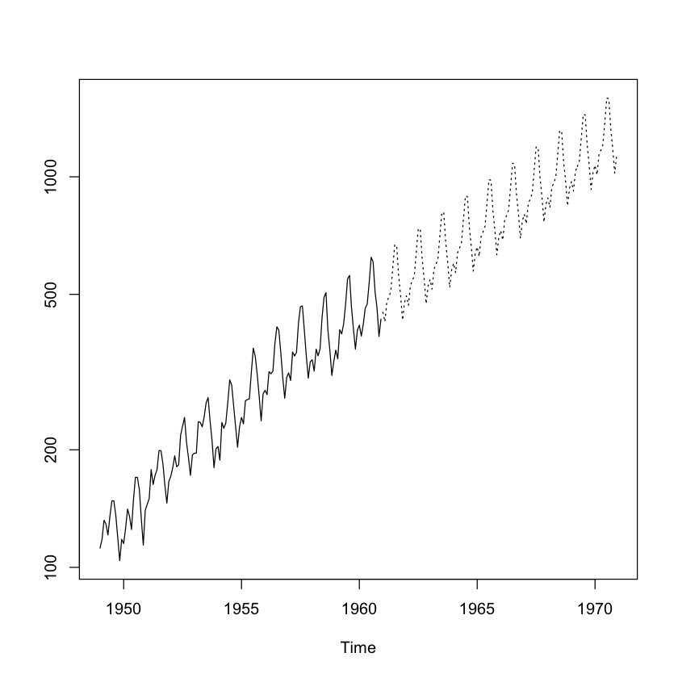

```r
ts.plot(AirPassengers,2.718^pred$pred, log = "y", lty = c(1,3))
```

```r
#testing of model
datawide<-ts(dataSet,frequency = 12,start = c(1949,1),end=c(1959,12))
```

```r
fitArima<-arima(log(datawide),c(0,1,1),seasonal = list(order=c(0,1,1),period=12))
fitArima
```

```
Call:
arima(x = log(datawide), order = c(0, 1, 1), seasonal = list(order = c(0, 1,
    1), period = 12))

Coefficients:
          ma1     sma1
      -0.3484  -0.5623
s.e.   0.0943   0.0774

sigma^2 estimated as 0.001313:  log likelihood = 223.63,  aic = -441.26
```

```r
pred<-predict(fitArima,n.ahead = 10*12)
pred1<-round(2.718^pred$pred,0)
data1=round(head(pred1,12),0)# prediction data
data2=round(tail(dataSet,12),0)# original data
pred1
data1
data2
```

[output not shown]

|  | Jan | Feb | Mar | Apr | May | Jun | Jul | Aug | Sep | Oct | Nov | Dec |
| --- | --- | --- | --- | --- | --- | --- | --- | --- | --- | --- | --- | --- |
| 1960 | 419 | 399 | 466 | 454 | 473 | 547 | 622 | 630 | 526 | 462 | 406 | 452 |
| 1961 | 470 | 447 | 522 | 509 | 530 | 613 | 697 | 706 | 590 | 518 | 455 | 506 |
| 1962 | 526 | 501 | 585 | 570 | 594 | 687 | 781 | 791 | 661 | 580 | 510 | 568 |
| 1963 | 590 | 561 | 656 | 639 | 665 | 769 | 875 | 886 | 741 | 650 | 572 | 636 |
| 1964 | 661 | 629 | 735 | 716 | 746 | 862 | 980 | 993 | 830 | 728 | 641 | 713 |
| 1965 | 740 | 704 | 824 | 802 | 836 | 966 | 1098 | 1112 | 930 | 816 | 718 | 798 |
| 1966 | 830 | 789 | 923 | 899 | 936 | 1082 | 1231 | 1247 | 1042 | 915 | 804 | 895 |
| 1967 | 930 | 884 | 1034 | 1007 | 1049 | 1213 | 1379 | 1397 | 1168 | 1025 | 901 | 1003 |
| 1968 | 1042 | 991 | 1159 | 1129 | 1176 | 1359 | 1545 | 1565 | 1308 | 1148 | 1010 | 1123 |
| 1969 | 1167 | 1110 | 1299 | 1265 | 1317 | 1523 | 1732 | 1754 | 1466 | 1287 | 1132 | 1259 |

1. 419

2. 399

3. 466

4. 454

5. 473

6. 547

7. 622

8. 630

9. 526

10. 462

11. 406

12. 452

1. 417

2. 391

3. 419

4. 461

5. 472

6. 535

7. 622

8. 606

9. 508

10. 461

11. 390

12. 432

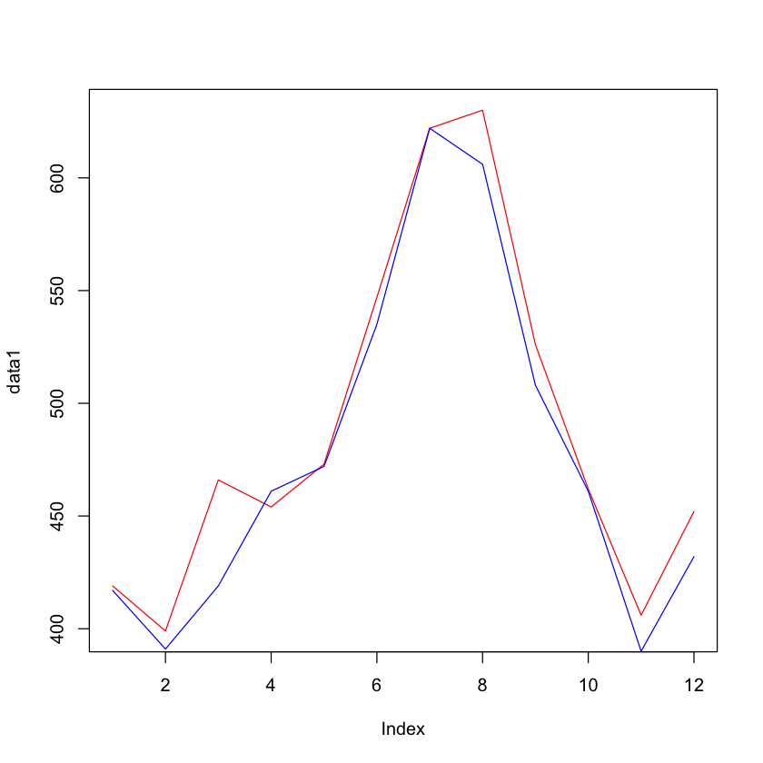

```r
plot(data1,col = "red",type="l")
lines(data2,col="blue")
```

```r
ts.plot(dataSet,)
```

[output not shown]

# Model Fitting

4.1 Trend Component

- Inspecting the trend component in the decomposition plot suggests that the relationship is linear, thus fitting a linear model:

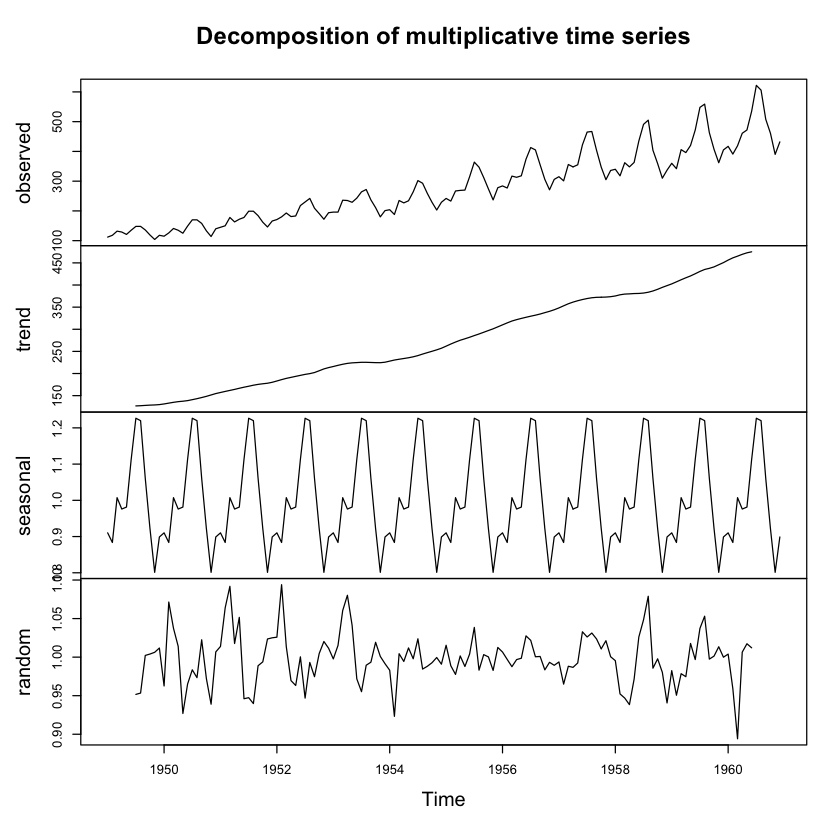

```r
dataSet.decompM<-decompose(dataSet, type = "multiplicative")
plot(dataSet.decompM)
```

```r
dataSet.decompM$seasonal
```

[output not shown]

|  | Jan | Feb | Mar | Apr | May | Jun | Jul | Aug | Sep | Oct | Nov | Dec |
| --- | --- | --- | --- | --- | --- | --- | --- | --- | --- | --- | --- | --- |
| 1949 | 0.9102304 | 0.8836253 | 1.0073663 | 0.9759060 | 0.9813780 | 1.1127758 | 1.2265555 | 1.2199110 | 1.0604919 | 0.9217572 | 0.8011781 | 0.8988244 |
| 1950 | 0.9102304 | 0.8836253 | 1.0073663 | 0.9759060 | 0.9813780 | 1.1127758 | 1.2265555 | 1.2199110 | 1.0604919 | 0.9217572 | 0.8011781 | 0.8988244 |
| 1951 | 0.9102304 | 0.8836253 | 1.0073663 | 0.9759060 | 0.9813780 | 1.1127758 | 1.2265555 | 1.2199110 | 1.0604919 | 0.9217572 | 0.8011781 | 0.8988244 |
| 1952 | 0.9102304 | 0.8836253 | 1.0073663 | 0.9759060 | 0.9813780 | 1.1127758 | 1.2265555 | 1.2199110 | 1.0604919 | 0.9217572 | 0.8011781 | 0.8988244 |
| 1953 | 0.9102304 | 0.8836253 | 1.0073663 | 0.9759060 | 0.9813780 | 1.1127758 | 1.2265555 | 1.2199110 | 1.0604919 | 0.9217572 | 0.8011781 | 0.8988244 |
| 1954 | 0.9102304 | 0.8836253 | 1.0073663 | 0.9759060 | 0.9813780 | 1.1127758 | 1.2265555 | 1.2199110 | 1.0604919 | 0.9217572 | 0.8011781 | 0.8988244 |
| 1955 | 0.9102304 | 0.8836253 | 1.0073663 | 0.9759060 | 0.9813780 | 1.1127758 | 1.2265555 | 1.2199110 | 1.0604919 | 0.9217572 | 0.8011781 | 0.8988244 |
| 1956 | 0.9102304 | 0.8836253 | 1.0073663 | 0.9759060 | 0.9813780 | 1.1127758 | 1.2265555 | 1.2199110 | 1.0604919 | 0.9217572 | 0.8011781 | 0.8988244 |
| 1957 | 0.9102304 | 0.8836253 | 1.0073663 | 0.9759060 | 0.9813780 | 1.1127758 | 1.2265555 | 1.2199110 | 1.0604919 | 0.9217572 | 0.8011781 | 0.8988244 |
| 1958 | 0.9102304 | 0.8836253 | 1.0073663 | 0.9759060 | 0.9813780 | 1.1127758 | 1.2265555 | 1.2199110 | 1.0604919 | 0.9217572 | 0.8011781 | 0.8988244 |
| 1959 | 0.9102304 | 0.8836253 | 1.0073663 | 0.9759060 | 0.9813780 | 1.1127758 | 1.2265555 | 1.2199110 | 1.0604919 | 0.9217572 | 0.8011781 | 0.8988244 |
| 1960 | 0.9102304 | 0.8836253 | 1.0073663 | 0.9759060 | 0.9813780 | 1.1127758 | 1.2265555 | 1.2199110 | 1.0604919 | 0.9217572 | 0.8011781 | 0.8988244 |

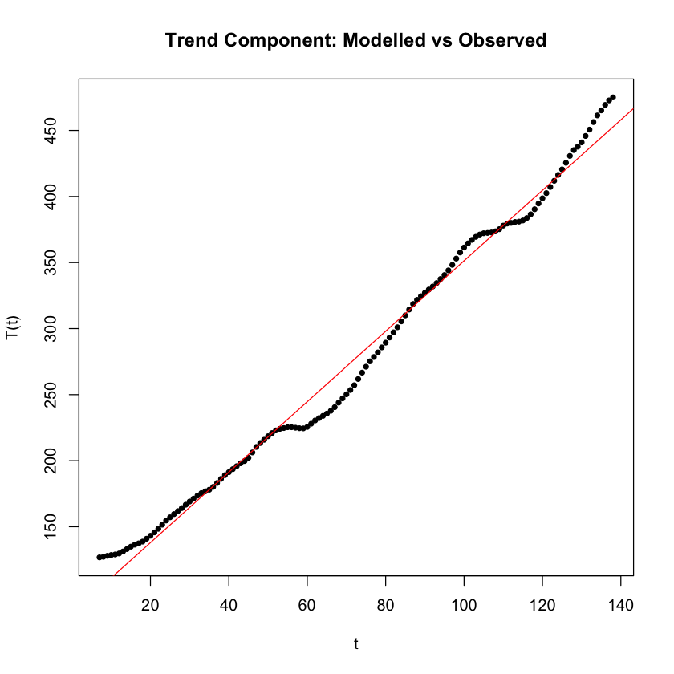

```r
t <- seq(1, 144, 1)
modelTrend <- lm(formula = dataSet.decompM$trend ~ t)
predT <- predict.lm(modelTrend, newdata = data.frame(t))

plot(dataSet.decompM$trend[7:138] ~ t[7:138], ylab="T(t)", xlab="t",
     type="p", pch=20, main = "Trend Component: Modelled vs Observed")
lines(predT, col="red")
```

# Conclusions